# Principios y Prácticas de SEM y MLM (5ed)

Tema 3.1 Modelos SEM - MIMIC

Author

Affiliation

Efraín García Sánchez

CIMCYC — Universidad de Granada

Published

May 22, 2026

# Principios

> “If a model is consistent with reality, then the data should be consistent with the model. BUT if the data are consistent with the model, this does not imply that the model corresponds to reality” (Keneth Bollen)

## ¿Qué tipos de preguntas de investigación abordan los SEM?

- Si una variable (observable o latente) se asocia con otra(s), controlando por otras variables del modelo (efectos directos sobre múltiples DV).
- Si el efecto de una variable sobre otra ocurre a través de una tercera variable. (efectos indirectos o mediación)
- Si hay diferencias entre grupos (e.g., MIMIC, Invarianza, Multigrupos, etc.)
- Si una variable en un tiempo 1 predice otra variable en un tiempo 2 (t_1 -> t_2) (e.g., CLPM, RI-CLPM, LGC)
- Y muchas más posibilidades (e.g., Multilevel-SEM, Dynamic SEM, Mixture modelling, etc.)

## Componentes de de los SEM

- **Modelo de medición** (CFA)
  - Representación de los constructos (factores)
  - Estructura y naturaleza de los datos
- **Modelo estructural** (e.g., egresiones, caminos)
  - Relaciones entre constructos (factores)
  - Parsimonia (correcta especificación)

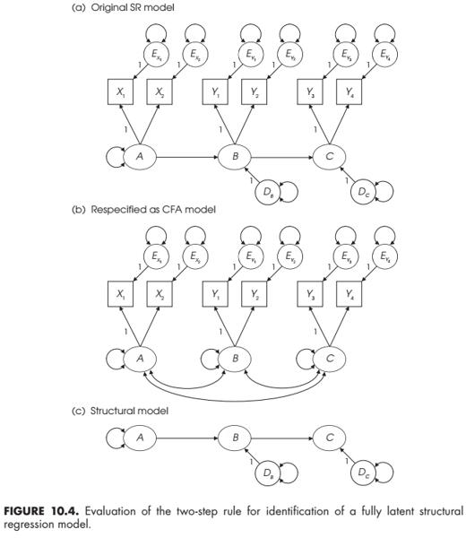

## Componentes de los SEM

- Variables
  - Latentes (estimadas/factores) vs. observables (datos/indicadores)
  - Exógenas (VI) vs. endógenas (VD)
- Varianzas
  - Varianza explicada ($R^2$)
  - Covarianzas: asociaciones entre constructos
  - Residuales: varianza no explicada (error + única)
- Parámetros
  - *Free* (estimados)
  - *Fixed* (predefinidos)
  - *Constrained* (según el modelo)

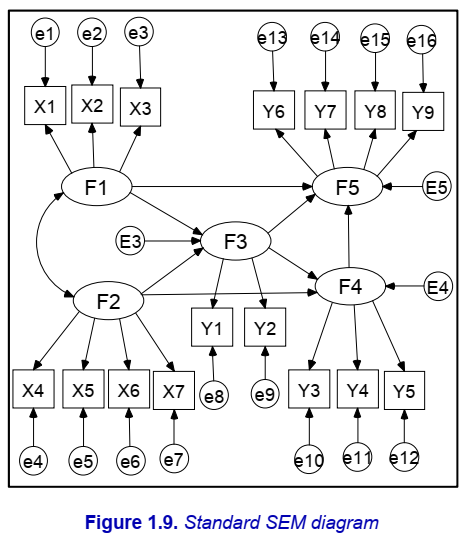

## Representación de un SEM

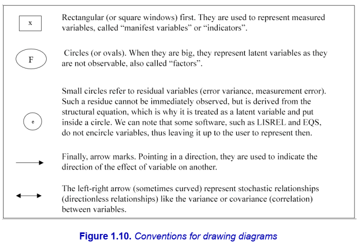

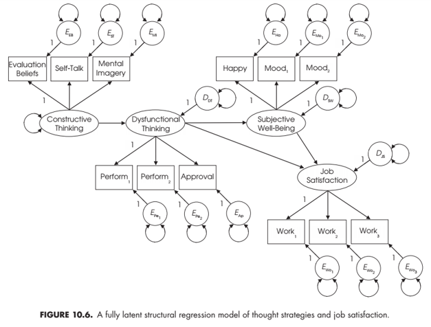

## Tipos de modelos SEM

- Full latent SEM
- Partially latent SEM

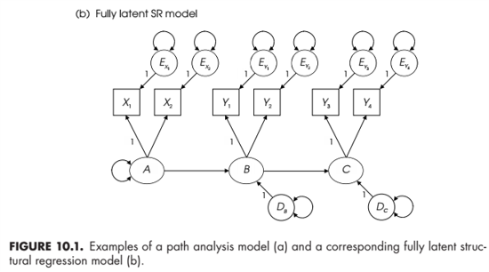

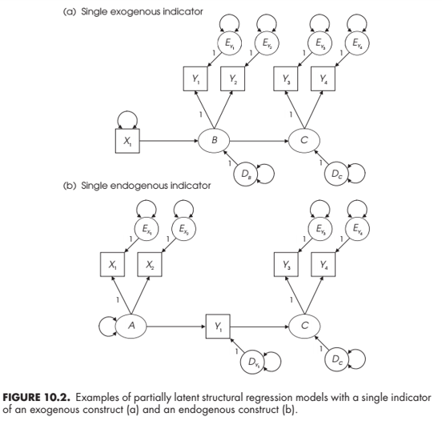

## Procedimiento para realizar un SEM

0. Preparación de los datos
1. Especificación del modelo (medida + estructural)
2. Estimación de los parámetros del modelo
3. Evaluación del modelo
4. Reespecificación del modelo (opcional)

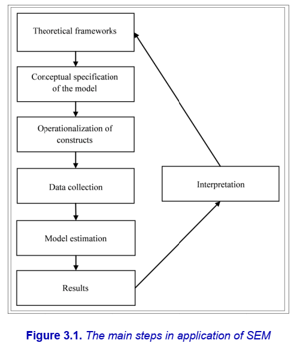

# Modelo MIMIC

## Multiple Indicator Multiple Independent Causes

- Evalúa la relación entre
  - variables exógeneas y observables
  - variables endógenas y latentes
- Ventajas
  - Controlar por covariables en el modelo
  - Comparar grupos (especialmente muestras pequeñas)
  - Más parsimonioso que un análisis multi-grupo
  - Alguna evidencia de invarianza (e.g., que no haya diferencias)

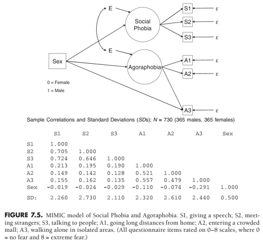

# Práctica: MIMIC

## Preparar el ambiente de trabajo

```r
library(tidyverse)
library(easystats)
library(tidySEM)      # para formatode salida de lavaan
library(lavaan)       # Para modelos SEM
library(semTools)     # Para fiabilidad y otros relacionadas con SEM
library(semPlot)
library(psych)
```

## Importar los datos: solo numéricos (recomendado para evitar conflictos con paquetes)

- Importar los datos

```r
data <- readr::read_csv(
  here::here("data",
  "northampton_student_health_data_package",
  "northampton_student_health_numeric.csv"))

glimpse(data)
```

```
Rows: 590
Columns: 61
$ id                             <dbl> 1, 2, 3, 4, 5, 6, 7, 8, 9, 10, 11, 12, …
$ age_group                      <dbl> 1, 1, 1, 1, 1, 1, 2, 4, 1, 1, 1, 1, 1, …
$ gender                         <dbl> 2, 1, 1, 1, 1, 2, 1, 1, 2, 2, 2, 2, 2, …
$ sexual_orientation             <dbl> 1, 2, 1, 3, 1, 1, 1, 1, 1, 1, 1, 1, 1, …
$ ethnicity                      <dbl> 1, 1, 1, 2, 1, 3, 1, 1, 1, 3, 1, 1, 1, …
$ study_mode                     <dbl> 1, 1, 1, 1, 1, 1, 1, 2, 1, 1, 1, 1, 1, …
$ study_level                    <dbl> 3, 3, 3, 3, 2, 6, 4, 3, 1, 2, 1, 1, 1, …
$ living_situation               <dbl> 1, 2, 1, 3, 2, 4, 3, 3, 1, 2, 4, 1, 1, …
$ phys_health                    <dbl> 3, 4, 4, 3, 4, 5, 5, 1, 4, 4, 4, 5, 5, …
$ ment_health                    <dbl> 4, 3, 2, 4, 3, 3, 2, 1, 4, 4, 3, 5, 3, …
$ social_connect                 <dbl> 4, 3, 1, 1, 2, 3, 2, 4, 4, 3, 3, 3, 2, …
$ sitting_weekday_hours          <dbl> 8, 5, 7, 9, NA, 5, 11, 13, 6, 5, 12, 6,…
$ sleep_quality                  <dbl> 8, 7, 4, 7, 2, 5, 3, 8, 7, 2, 9, 7, 3, …
```

[output cut: 48 more lines]

## Preparar los datos

```r
data <- data |>
  mutate(# creo variable dummy para género (Female vs Male)
         gender_female = case_when(gender == 1 ~ 1, # Female
                                   gender == 2 ~ 0, # Male
                                   .default = NULL),
         # creo una variable de etnia para los grupos más grandes
         ethnicity_cat = case_when(ethnicity == 1 ~ "White",
                                 ethnicity == 3 ~ "Black",
                                 ethnicity == 4 ~ "Asian",
                                 TRUE ~ NA_character_),
         # ordeno la variable de etnia en niveles (White es la referencia)
         ethnicity_cat = factor(ethnicity_cat,
                                levels = c("White", "Black", "Asian")),
         # Creo una variable dummy para ver diferencias con White
         ethnicity_black = ifelse(test = ethnicity_cat == "Black",
                                  yes = 1, no = 0),
         ethnicity_asian = ifelse(test = ethnicity_cat == "Asian",
                                  yes = 1, no = 0),
         # creo una variable categórica con pa_activity
         pa_activity_level_cat = case_when(pa_activity_level == 0 ~ "0_Inactive",
                                       pa_activity_level == 1 ~ "1_Fairly_Active",
                                       pa_activity_level == 2 ~ "2_Active")
         )
```

## MIMIC: Especificar y estimar el modelo de medición

```r
m1 <- 'wellbeing =~ ment_health + phys_health + social_connect + sleep_quality'

# Estimar el modelo
m1_fit <- lavaan::sem(
  m1,
  estimator = "MLR",
  data = data
)

# resumen del modelo
summary(m1_fit,
        std = TRUE,
        ci = TRUE,
        fit.measures = TRUE)  # muestra los intervalos de confianza
```

```
lavaan 0.6-21 ended normally after 20 iterations

  Estimator                                         ML
  Optimization method                           NLMINB
  Number of model parameters                         8

  Number of observations                           590

Model Test User Model:
                                              Standard      Scaled
  Test Statistic                                 5.627       5.503
  Degrees of freedom                                 2           2
  P-value (Chi-square)                           0.060       0.064
  Scaling correction factor                                  1.023
    Yuan-Bentler correction (Mplus variant)

Model Test Baseline Model:

  Test statistic                               447.060     390.865
  Degrees of freedom                                 6           6
  P-value                                        0.000       0.000
  Scaling correction factor                                  1.144

User Model versus Baseline Model:

  Comparative Fit Index (CFI)                    0.992       0.991
  Tucker-Lewis Index (TLI)                       0.975       0.973

  Robust Comparative Fit Index (CFI)                         0.992
  Robust Tucker-Lewis Index (TLI)                            0.976

Loglikelihood and Information Criteria:

  Loglikelihood user model (H0)              -3491.564   -3491.564
  Scaling correction factor                                  1.043
      for the MLR correction
  Loglikelihood unrestricted model (H1)      -3488.751   -3488.751
  Scaling correction factor                                  1.039
      for the MLR correction

```

[output cut: 40 more lines]

```
    0.946    0.470

Variances:
                   Estimate  Std.Err  z-value  P(>|z|) ci.lower ci.upper
   .ment_health       0.245    0.071    3.435    0.001    0.105    0.384
   .phys_health       0.495    0.039   12.850    0.000    0.419    0.570
   .social_connect    0.744    0.048   15.549    0.000    0.650    0.838
   .sleep_quality     3.163    0.197   16.056    0.000    2.777    3.549
    wellbeing         0.864    0.093    9.265    0.000    0.681    1.046
   Std.lv  Std.all
    0.245    0.221
    0.495    0.649
    0.744    0.744
    3.163    0.779
    1.000    1.000
```

## MIMIC: Visualizar el modelo de medición (opcional)

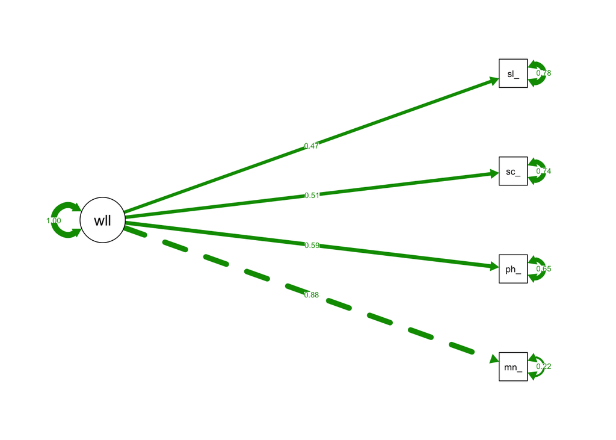

```r
semPlot::semPaths(m1_fit,
         what = "std",
         rotation = 2,
         fade = FALSE)
```

## Modelo MIMIC: Especificar el modelo estructural

```r
m2 <- '
# Modelo de Medición
wellbeing =~ ment_health + phys_health + social_connect + sleep_quality

# Modelo Estructural
wellbeing ~ gender_female + age_group
'
```

## Modelo MIMIC: Estimar el modelo estructural

```r
# Estimar el modelo
m2_fit <- lavaan::sem(
  m2,
  estimator = "MLR",
  data = data
)
```

## Modelo MIMIC: Evaluar el modelo estructural

```r
# resumen del modelo
summary(m2_fit,
        std = TRUE,
        ci = TRUE,             # muestra los intervalos de confianza
        fit.measures = TRUE)   # muestra los índices de ajuste
```

```
lavaan 0.6-21 ended normally after 22 iterations

  Estimator                                         ML
  Optimization method                           NLMINB
  Number of model parameters                        10

                                                  Used       Total
  Number of observations                           573         590

Model Test User Model:
                                              Standard      Scaled
  Test Statistic                                20.792      20.593
  Degrees of freedom                                 8           8
  P-value (Chi-square)                           0.008       0.008
  Scaling correction factor                                  1.010
    Yuan-Bentler correction (Mplus variant)

Model Test Baseline Model:

  Test statistic                               504.905     476.700
  Degrees of freedom                                14          14
  P-value                                        0.000       0.000
  Scaling correction factor                                  1.059

User Model versus Baseline Model:

  Comparative Fit Index (CFI)                    0.974       0.973
  Tucker-Lewis Index (TLI)                       0.954       0.952

  Robust Comparative Fit Index (CFI)                         0.974
  Robust Tucker-Lewis Index (TLI)                            0.955

Loglikelihood and Information Criteria:

  Loglikelihood user model (H0)              -3343.511   -3343.511
  Scaling correction factor                                  1.035
      for the MLR correction
  Loglikelihood unrestricted model (H1)      -3333.115   -3333.115
  Scaling correction factor                                  1.024
      for the MLR correction
```

[output cut: 51 more lines]

```
    0.299    0.272

Variances:
                   Estimate  Std.Err  z-value  P(>|z|) ci.lower ci.upper
   .ment_health       0.187    0.065    2.851    0.004    0.058    0.315
   .phys_health       0.515    0.039   13.165    0.000    0.438    0.591
   .social_connect    0.737    0.049   15.162    0.000    0.642    0.832
   .sleep_quality     3.170    0.195   16.230    0.000    2.787    3.553
   .wellbeing         0.780    0.082    9.499    0.000    0.619    0.941
   Std.lv  Std.all
    0.187    0.174
    0.515    0.679
    0.737    0.742
    3.170    0.798
    0.884    0.884
```

## Modelo MIMIC: Evaluar el modelo

```r
lavaan::fitmeasures(m2_fit,
                    output = "text")
```

```
Model Test User Model:

                                              Standard      Scaled
  Test statistic                                20.792      20.593
  Degrees of freedom                                 8           8
  P-value                                        0.008       0.008
  Average scaling correction factor                          1.010

Model Test Baseline Model:

  Test statistic                               504.905     476.700
  Degrees of freedom                                14          14
  P-value                                        0.000       0.000
  Scaling correction factor                                  1.059

User Model versus Baseline Model:

  Comparative Fit Index (CFI)                    0.974       0.973
  Tucker-Lewis Index (TLI)                       0.954       0.952

  Robust Comparative Fit Index (CFI)                         0.974
  Robust Tucker-Lewis Index (TLI)                            0.955
  Bentler-Bonett Non-normed Fit Index (NNFI)     0.954       0.955
  Bentler-Bonett Normed Fit Index (NFI)          0.959       0.957
  Parsimony Normed Fit Index (PNFI)              0.548       0.547
  Bollen's Relative Fit Index (RFI)              0.928       0.924
  Bollen's Incremental Fit Index (IFI)           0.974       0.973
  Relative Noncentrality Index (RNI)             0.974       0.974

Loglikelihood and Information Criteria:

  Loglikelihood user model (H0)              -3343.511   -3343.511
  Scaling correction factor                                  1.035
      for the MLR correction
  Loglikelihood unrestricted model (H1)      -3333.115   -3333.115
  Scaling correction factor                                  1.024
      for the MLR correction

  Akaike (AIC)                                6707.022    6707.022
  Bayesian (BIC)                              6750.531    6750.531
```

[output cut: 19 more lines]

```
  RMR (No Mean)                                  0.050       0.050
  SRMR                                           0.032       0.032

Other Fit Indices:

  Hoelter Critical N (CN) alpha = 0.05         428.354     428.354
  Hoelter Critical N (CN) alpha = 0.01         554.651     554.651

  Goodness of Fit Index (GFI)                    0.983       0.983
  Adjusted Goodness of Fit Index (AGFI)          0.955       0.955
  Parsimony Goodness of Fit Index (PGFI)         0.374       0.374

  McDonald Fit Index (MFI)                       0.989       0.989

  Expected Cross-Validation Index (ECVI)         0.071       0.071
```

## Modelo MIMIC: Evaluar el modelo (algunas orientaciones)

```r
effectsize::interpret(m2_fit)
```

```
    Name      Value Threshold Interpretation
1    GFI 0.98277574      0.95   satisfactory
2   AGFI 0.95478630      0.90   satisfactory
3    NFI 0.95881933      0.90   satisfactory
4   NNFI 0.95439734      0.90   satisfactory
5    CFI 0.97394134      0.90   satisfactory
6  RMSEA 0.05282659      0.05           poor
7   SRMR 0.03248029      0.08   satisfactory
8    RFI 0.92793383      0.90   satisfactory
9   PNFI 0.54789676      0.50   satisfactory
10   IFI 0.97425599      0.90   satisfactory
```

## Reportar el modelo MIMIC

```r
parameters::parameters(m2_fit)
```

```
# Loading

Link                        | Coefficient |   SE |       95% CI |     z |      p
--------------------------------------------------------------------------------
wellbeing =~ ment_health    |        1.00 | 0.00 | [1.00, 1.00] |       | < .001
wellbeing =~ phys_health    |        0.53 | 0.05 | [0.43, 0.62] | 11.15 | < .001
wellbeing =~ social_connect |        0.54 | 0.06 | [0.42, 0.66] |  8.90 | < .001
wellbeing =~ sleep_quality  |        0.95 | 0.12 | [0.72, 1.19] |  8.11 | < .001

# Regression

Link                      | Coefficient |   SE |         95% CI |     z |      p
--------------------------------------------------------------------------------
wellbeing ~ gender_female |       -0.40 | 0.09 | [-0.58, -0.23] | -4.49 | < .001
wellbeing ~ age_group     |        0.28 | 0.05 | [ 0.19,  0.37] |  6.25 | < .001

# Correlation

Link                       | Coefficient | SE |         95% CI |      p
-----------------------------------------------------------------------
gender_female ~~ age_group |       -0.01 |  0 | [-0.01, -0.01] | < .001
```

## Visualizar el modelo MIMIC (opcional)

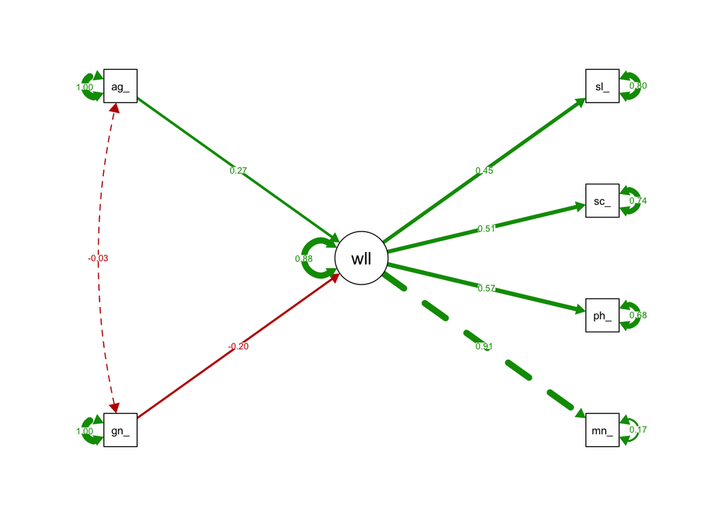

```r
semPlot::semPaths(m2_fit,
         what = "std",
         rotation = 2,
         fade = FALSE)
```

# Ejercicio: MIMIC

## Instrucciones

Vamos a adaptar la práctica para estimar un modelo MIMIC con **dos variables latentes** y cuatro predictores observados.

### Modelo de medición

- **wellbeing**: factor latente de bienestar, medido por:
  - **ment_health**
  - **phys_health**
  - **social_connect**
  - **sleep_quality**
- **substances**: factor latente de consumo de sustancias, medido por:
  - **caffeine_non_exam**
  - **alcohol_freq**
  - **nicotine_freq**

### Modelo estructural

Ambos factores latentes serán predichos por:

- **gender_female**: variable dummy, 1 = mujer, 0 = hombre.
- **age_group**: grupo de edad.
- **pa_importance**: importancia atribuida a la actividad física.
- **sitting_weekday_hours**: horas de sedentarismo entre semana.

## Instrucciones

### Tareas

1. Especificar el modelo MIMIC en sintaxis de **lavaan**, incluyendo el modelo de medición y el modelo estructural.
2. Estimar el modelo con **lavaan::sem()** y estimador robusto **MLR**.
3. Revisar el resumen general del modelo
4. Evaluar el ajuste global del modelo con índices robustos e interpretaciones orientativas.
5. Inspeccionar el modelo de medición, prestando atención a las cargas factoriales de **wellbeing** y **substances**.
6. Inspeccionar el modelo estructural, prestando atención a los efectos de **gender_female**, **age_group**, **pa_importance** y **sitting_weekday_hours**.
7. Visualizar el modelo estimado.
8. Pensar una conclusión sustantiva breve que integre ajuste global, medición y relaciones estructurales.

# Escribir tu respuesta aquí